# Model on over-dispersion microbiome count data using HMP data as a case study

David Xin Zhao

2022-12-02

## Basic principles of models

1. What is “over dispersion”?
- Over dispersion is the presence of greater variability in a data set than would be expected based on a given statistical model. - Over dispersion destroys the assumption of Poisson regression that mean (nearly) equals to variance.
- Microbiome count data is typically over dispersed.
- In a result, Poisson regression is not suitable to fit microbiome count data, though microbiome count distribution is similar to Poisson distribution in some way.
2. Negative Binomial (NB) regression:
- The most common alternative to Poisson model, accounting for over dispersion.
- NB model includes an additional gamma parameter to regress a non-linear relationship between variance and mean.
3. R packages to implement NB regression:
- `edgeR` package: One of most popular implementations of variance stabilization technique used in RNA-Seq analysis and can be adapted for microbiome count data. The edgeR package implements an exact binomial test, which generalized for over dispersed counts via the function `exactTest()`.
- `DESeq`/ `DESeq2` package

## Steps to implement NB model with R packages

### `edgeR` pakcage

1. Load data set and step up the count matrix
2. Build the edgeR object
3. Filter the data
4. Normalize the data
5. Explore the data by multi-dimensional scaling (MDS) plot
6. Estimate the dispersion
7. Test the differential abundance
8. Interpret the results of differential expression analysis with diagnostic plots

### `DESeq2` package

1. Create the count table
2. Create the sample metadata table
3. Build the DESeq2 object
4. Filter the data
5. Normalize the count data
6. Estimate the dispersion
7. Test the differential abundance
8. Diagnose and improve the testing results
9. Extract differentially abundant OTUs and export results table

## Load necessary libraries

```r
library(tidyverse)
library(edgeR)
library(statmod)
```

## R pipeline with `edgeR` package

### Step 1 Load data set and step up the count matrix

Prepare a OTUs-by-samples format data according to edgeR input data requirement.

The 16S abundance data and metadata was retrieved from the [Inflammatory Bowel Disease Multi’omics Database](https://ibdmdb.org/tunnel/public/HMP2/16S/1806/products).

```r
# read in 16S abundance/ count data in HMP2 database
untar("hmp2_abund.tar", exdir = getwd()) # unzip a .tar file

abund_raw <- read_tsv("taxonomic_profiles.tsv.gz",
                      show_col_types = FALSE) %>%
        as.data.frame()


mat_abund_raw <- abund_raw %>%
        select(-taxonomy) %>%
        column_to_rownames("#OTU ID") %>%
        as.matrix()
```

Read in the metadata in `.csv` format.

```r
# read in the meta data
meta_raw <- read.csv("hmp2_metadata.csv")
```

Subset identifiers, environmental/ clinical variables of my research interest, including `Project`, `External.ID`, `Participant.ID`, `week_num`, `biopsy_location`, `diagnosis` and `Age.at.diagnosis`.

```r
meta_raw_sub <- meta_raw %>%
        select(Project,
               External.ID,
               Participant.ID,
               diagnosis,
               week_num,
               biopsy_location,
               Age.at.diagnosis)
```

Merge 16S abundance data and subset metadata.

```r
# reshape abundance data
abund_raw_id <- abund_raw %>%
        gather(key="sample_id",
               value = "read",
               -c("#OTU ID", "taxonomy"))

# join two data frames by "id" = "External.ID"
abund_meta <- abund_raw_id %>%
        inner_join(meta_raw_sub,
                   by = c("sample_id" = "External.ID"))
```

The microbiome 16S abundance data set contains data points from 81 participants; the biopsy were collected from 7 different locations, including `Rectum`, `Ileum`, `Sigmoid Colon`, `Descending (left-sided) colon`, `Cecum`, `Ascending (right-sided) colon`, and `Transverse colon`. For the simplicity purpose, I focused on rectum biopsy data for the subsequent analysis.

```r
abund_meta_rectum <- abund_meta %>%
        filter(biopsy_location == "Rectum")
```

Collapse taxonomy at the genus level, namely similarity equals or higher than 97%

```r
abund_meta_rectum2 <- abund_meta_rectum %>%
        mutate(genus = str_split_fixed(abund_meta_rectum$taxonomy, "; __", 6)[,6]) %>%
        mutate(genus_rep = case_when(genus == "g" ~ "unclassified",
                                     genus != "g" ~ genus)) %>%
        select(-genus)
```

```r
abund_meta_rectum3 <- abund_meta_rectum2 %>%
        rename(otu = "#OTU ID") %>%
        select(sample_id, Participant.ID, read, diagnosis, otu) %>%
        rename(subject_id = Participant.ID)

df_total_reads <- abund_meta_rectum3 %>%
        group_by(sample_id) %>%
        summarise(lib_size = sum(read)) %>%
        ungroup()

abund_meta_rectum4 <- abund_meta_rectum3 %>%
        left_join(df_total_reads, by="sample_id")


# convert to the factor variable with new levels
abund_meta_rectum4$diagnosis <- factor(abund_meta_rectum4$diagnosis,
                                       levels = c("nonIBD", "CD", "UC"))
```

### Step 2 Build the edgeR object

The edgeR stores data in a simple list-based data object called a `DGEList`.

First, create a grouping variable or extract grouping information from the meta data, telling the edgeR which samples belong to which group. And then specify the count matrix and the groups in the function `DGEList()`.

Prior to building the edgeR object, make sure dimensions of the count matrix is equal to length of the grouping variable, `diagnosis`.

```r
mat_count <- abund_meta_rectum4 %>%
        select(sample_id, otu, read) %>%
        spread(sample_id, read) %>%
        column_to_rownames("otu") %>%
        as.matrix()

dim(mat_count)  # 89 distinct samples
```

```
## [1] 982  89
```

```r
groups <- abund_meta_rectum4 %>%
        filter(sample_id %in% colnames(mat_count)) %>%
        group_by(sample_id) %>%
        filter(row_number()==1) %>%
        pull(diagnosis)

length(groups)  # 89 distinct samples
```

```
## [1] 89
```

```r
y <- DGEList(counts = mat_count, group = groups)
```

Use the $ symbol to access elements of the edgeR object. Original count matrix

```r
head(y$counts)
```

```
##          206538 206548 206561 206562 206570 206572 206605 206609 206615 206619
## A6BMetha      0      0      0      0      0      0      0      0      0      0
## A6BRick6      0      0      0      0      0      0      0      0      0      0
## A6BStoq4      0      0      0      0      0      0      0      0      0      0
## BcsCoa64      0      0      0      0      0      0      0      0      0      0
## BcsS4691      0      0      0      0      0      0      0      0      0      0
## C80Tra95      0      0      0      0      0      0      0      0      0      0
##          206621 206624 206628 206630 206636 206644 206646 206648 206656 206658
## A6BMetha      0      0      0      0      0      0      0      0      0      0
## A6BRick6      0      0      0      0      0      0      0      0      0      0
## A6BStoq4      0      0      0      0      0     15      0      0      0      0
## BcsCoa64      0      0      0      0      0      0      0      0      0      0
## BcsS4691      0      0      0      0      0      0      0      0      0      0
## C80Tra95      0      0      0      0      0      0      0      0      0      0
##          206660 206668 206670 206672 206673 206676 206678 206682 206684 206695
## A6BMetha      0      0      0      0      0      0      0      0      0      0
## A6BRick6      0      0      0      0      0      0      0      0      0      0
## A6BStoq4      0      0      0      0      0      0      0      0      0      0
## BcsCoa64      0      0      0      0      0      0      0      0      0      0
## BcsS4691      0      0      0      0      0      0      0      0      0      0
## C80Tra95      0      0      0      0      0      0      0      0      0      0
##          206700 206701 206704 206709 206711 206713 206719 206720 206723 206726
## A6BMetha      0      0      0      0      0      0      0      0      0      0
## A6BRick6      0      0      0      0      0      0      0      0      0      0
## A6BStoq4      0      0      0      0      0      0      0      0      0      0
## BcsCoa64      0      0      0      0      0      0      0      0      0      0
## BcsS4691      0      0      0      0      0      0      0      0      0      0
## C80Tra95      0      0      0      0      0      0      0      0      0      0
##          206727 206730 206732 206734 206739 206741 206742 206747 206751 206753
## A6BMetha      0      0      0      0      0      0      0      0      0      0
## A6BRick6      0      0      0      0      0      0      0      0      0      0
## A6BStoq4      0      0      0      0      0      0      0      0      0      0
## BcsCoa64      0      0      0      0      0      0      0      0      0      0
## BcsS4691      0      0      0      0      0      0      0      0      0      0
## C80Tra95      0      0      0      0      0      0      0      0      0     10
##          206754 206755 206757 206762 206767 206769 206770 214995 215004 215008
## A6BMetha      0      0      0      0      0      0      0      0      0      0
## A6BRick6      0      0      0      0      0      0      0      0      0      0
## A6BStoq4      0      0      0      0      0      0      0      0      0      0
## BcsCoa64      0      0      0      0      0      1      0      0      0      0
```

[output cut: 8 more lines]

```
## C80Tra95      0      0      0      0      0      0      0      0      0      0
##          219633 219637 219643 219646 219651 219654 219656 219658 219668 219669
## A6BMetha      0      0      0      0      0      0      0      0      0      0
## A6BRick6      0      0      0      0      0      0      0      0      0      0
## A6BStoq4      0      0      0      0      0      0      0      0      0      0
## BcsCoa64      0      0      0      0      0      0      0      0      0      0
## BcsS4691      0      0      0      0      0      0      0      0      0      0
## C80Tra95      0      0      0      0      0      0      0      0      0      0
##          219675 219691 219693 222170 224324 224326 224328 224330 224844
## A6BMetha      0      0      0      0      0      0      0      0      0
## A6BRick6      0      0      0      0      0      0      0      0      0
## A6BStoq4      0      0      0      0      0      0      0      0      0
## BcsCoa64      0      0      0      0      0      0      0      0      0
## BcsS4691      0      0      0      0      0      0      0      0      0
## C80Tra95      0      0      0      0      0      0      0      0      0
```

A summary of samples

```r
y$samples
```

```
##         group lib.size norm.factors
## 206538     CD     8812            1
## 206548 nonIBD     4308            1
## 206561     CD     8789            1
## 206562     UC    14092            1
## 206570     UC    28645            1
## 206572     CD    14180            1
## 206605 nonIBD    15041            1
## 206609     UC    10153            1
## 206615     CD     5253            1
## 206619     UC     3220            1
## 206621     UC       34            1
## 206624     CD      716            1
## 206628     UC      308            1
## 206630     UC     6926            1
```

[output cut: 75 more lines]

How many genes have 0 counts across all samples

```r
sum(y$all.zeros)
```

```
## [1] 0
```

### Step 3 Filter the data

- Purpose to filter the data is to effectively detect truly differentially expressed genes or abundant taxa and conduct downstream analysis. In early stage, removes every low abundant taxa in any experimental conditions before processing the normalization and differential abundance testing.
- To choose an optimal filtering threshold is the key in data filtering.

The edgeR function uses CPM filter. CPM represents counts per million, calculated as the raw counts divided by the library sizes and multiplied by one million.

For instance, we choose a cutoff, such as, at least 100 counts per million (calculated with cpm() in R) in more number of samples (i.e., 10) to remove those genes (taxa) with a CPM value less then this cutoff from the analysis. The number of samples should be larger than the size of the smallest group.

Keep an OTU with CPM of 100 in greater at least two samples.

```r
dim(y)
```

```
## [1] 982  89
```

```r
y_full <- y # archive the old one in case I mess up

head(y$counts, 5)
```

```
##          206538 206548 206561 206562 206570 206572 206605 206609 206615 206619
## A6BMetha      0      0      0      0      0      0      0      0      0      0
## A6BRick6      0      0      0      0      0      0      0      0      0      0
## A6BStoq4      0      0      0      0      0      0      0      0      0      0
## BcsCoa64      0      0      0      0      0      0      0      0      0      0
## BcsS4691      0      0      0      0      0      0      0      0      0      0
##          206621 206624 206628 206630 206636 206644 206646 206648 206656 206658
## A6BMetha      0      0      0      0      0      0      0      0      0      0
## A6BRick6      0      0      0      0      0      0      0      0      0      0
## A6BStoq4      0      0      0      0      0     15      0      0      0      0
## BcsCoa64      0      0      0      0      0      0      0      0      0      0
## BcsS4691      0      0      0      0      0      0      0      0      0      0
##          206660 206668 206670 206672 206673 206676 206678 206682 206684 206695
## A6BMetha      0      0      0      0      0      0      0      0      0      0
## A6BRick6      0      0      0      0      0      0      0      0      0      0
## A6BStoq4      0      0      0      0      0      0      0      0      0      0
## BcsCoa64      0      0      0      0      0      0      0      0      0      0
## BcsS4691      0      0      0      0      0      0      0      0      0      0
##          206700 206701 206704 206709 206711 206713 206719 206720 206723 206726
## A6BMetha      0      0      0      0      0      0      0      0      0      0
## A6BRick6      0      0      0      0      0      0      0      0      0      0
## A6BStoq4      0      0      0      0      0      0      0      0      0      0
## BcsCoa64      0      0      0      0      0      0      0      0      0      0
## BcsS4691      0      0      0      0      0      0      0      0      0      0
##          206727 206730 206732 206734 206739 206741 206742 206747 206751 206753
## A6BMetha      0      0      0      0      0      0      0      0      0      0
## A6BRick6      0      0      0      0      0      0      0      0      0      0
## A6BStoq4      0      0      0      0      0      0      0      0      0      0
## BcsCoa64      0      0      0      0      0      0      0      0      0      0
## BcsS4691      0      0      0      0      0      0      0      0      0      0
##          206754 206755 206757 206762 206767 206769 206770 214995 215004 215008
## A6BMetha      0      0      0      0      0      0      0      0      0      0
## A6BRick6      0      0      0      0      0      0      0      0      0      0
## A6BStoq4      0      0      0      0      0      0      0      0      0      0
## BcsCoa64      0      0      0      0      0      1      0      0      0      0
## BcsS4691      0      0      0      0      0      0      0      0      0      0
##          215010 215049 215050 215056 215058 215062 215074 215075 215080 215085
## A6BMetha      0      0      0      0      0      0      0      0      0      0
## A6BRick6      0      0      0      0      0      0      0      0      2      0
## A6BStoq4      0      0      1     25      0      0      5      0      0      0
## BcsCoa64      0      0      0      0      0      0      0      0      0      0
## BcsS4691      0      0      0      0      0      0      0      0      0      0
##          219633 219637 219643 219646 219651 219654 219656 219658 219668 219669
## A6BMetha      0      0      0      0      0      0      0      0      0      0
## A6BRick6      0      0      0      0      0      0      0      0      0      0
## A6BStoq4      0      0      0      0      0      0      0      0      0      0
## BcsCoa64      0      0      0      0      0      0      0      0      0      0
## BcsS4691      0      0      0      0      0      0      0      0      0      0
##          219675 219691 219693 222170 224324 224326 224328 224330 224844
## A6BMetha      0      0      0      0      0      0      0      0      0
## A6BRick6      0      0      0      0      0      0      0      0      0
## A6BStoq4      0      0      0      0      0      0      0      0      0
## BcsCoa64      0      0      0      0      0      0      0      0      0
## BcsS4691      0      0      0      0      0      0      0      0      0
```

```r
apply(y$counts, 2, sum) # total OTU per sample
```

```
## 206538 206548 206561 206562 206570 206572 206605 206609 206615 206619 206621
##   8812   4308   8789  14092  28645  14180  15041  10153   5253   3220     34
## 206624 206628 206630 206636 206644 206646 206648 206656 206658 206660 206668
##    716    308   6926    548   5879  23607  17045   1736  16336  19927    609
## 206670 206672 206673 206676 206678 206682 206684 206695 206700 206701 206704
##  26676  11349  14326   5787   8474    409  22707    966  30151   7689  18517
## 206709 206711 206713 206719 206720 206723 206726 206727 206730 206732 206734
##  21885  23091  20968  23409  27369     81  23914  26247   7428  23353  31781
## 206739 206741 206742 206747 206751 206753 206754 206755 206757 206762 206767
##  26476  23048  24279  19029  25424  25890  21156  24748  24419  16704  11623
## 206769 206770 214995 215004 215008 215010 215049 215050 215056 215058 215062
##    542  26039  17717    504   8618  20287    286  23536  15753  14652  11322
## 215074 215075 215080 215085 219633 219637 219643 219646 219651 219654 219656
##   7381  19713  20619   4296  16230     80  18868  21143  23639  16459   9795
## 219658 219668 219669 219675 219691 219693 222170 224324 224326 224328 224330
##    917    625  23962  16661  16594   8316   6751  23232  29862  26163  20910
## 224844
##  11032
```

```r
keep <- rowSums(cpm(y) > 100) >= 2

y <- y[keep, ]

dim(y) # 402 OTU pass the filter threshold
```

```
## [1] 402  89
```

```r
y$samples$lib.size <- colSums(y$counts)

y$samples
```

```
##         group lib.size norm.factors
## 206538     CD     8801            1
## 206548 nonIBD     4281            1
## 206561     CD     8789            1
## 206562     UC    14086            1
## 206570     UC    28624            1
## 206572     CD    14167            1
## 206605 nonIBD    14857            1
## 206609     UC    10149            1
## 206615     CD     5233            1
## 206619     UC     3196            1
## 206621     UC       34            1
## 206624     CD      543            1
## 206628     UC      285            1
## 206630     UC     6891            1
```

[output cut: 75 more lines]

### Step 4 Normalize the data

Normalization is used to ensure the parameters are comparable because different libraries are sequenced to different depths.

First, calculate the normalization factors to correct for the different compositions of the samples.

In edgeR, RNA or DNA composition is normalized by finding a set of scaling factors for the library sizes that minimize the log-fold changes between the samples for most OTUs.

The `calcNormaFactors()` function is used to a set of scaling factors. The default method for calculating these scale factors uses the TMM method (Trimmed Mean of M-values) to calculate normalization factors between samples.

```r
y <- calcNormFactors(y)

y
```

```
## An object of class "DGEList"
## $counts
##          206538 206548 206561 206562 206570 206572 206605 206609 206615 206619
## A6BStoq4      0      0      0      0      0      0      0      0      0      0
## CsrNeon2      0      0      0      0      0      0      0      0      0      0
## CsrSp463      0      0    131    627    360      0      0      0      0      0
## CsrSpe61      0      0      0      0      0      0      0      0      0      0
## F1NAe698      0      0      0      0      0      0     25      0      0      0
##          206621 206624 206628 206630 206636 206644 206646 206648 206656 206658
## A6BStoq4      0      0      0      0      0     15      0      0      0      0
## CsrNeon2      0      0      0      0      0      0      1      0      0      0
## CsrSp463      0      0      0      0      0      0      0      0      0      0
## CsrSpe61      0      0      0      0      0      0      0      0      0      0
## F1NAe698      0      9      0      0      0      0      0      0      0      0
##          206660 206668 206670 206672 206673 206676 206678 206682 206684 206695
## A6BStoq4      0      0      0      0      0      0      0      0      0      0
## CsrNeon2      0      0      0      0      0      0      0      0      0      0
## CsrSp463      0      0      0      0      0      0      0      0      0      0
## CsrSpe61      0      0      0      0      0      0      0      0      0      0
## F1NAe698      0      0      0      0      0      0      0      0      0      0
##          206700 206701 206704 206709 206711 206713 206719 206720 206723 206726
## A6BStoq4      0      0      0      0      0      0      0      0      0      0
## CsrNeon2     23      0      0      0      0      0      0      0      0      0
## CsrSp463      0      0      0      0      0      0      0      0      0      0
## CsrSpe61      0      0      0      0      0      0      0      0      0      0
## F1NAe698      1      0      2      0      0      1      0      1      0      0
##          206727 206730 206732 206734 206739 206741 206742 206747 206751 206753
## A6BStoq4      0      0      0      0      0      0      0      0      0      0
## CsrNeon2      0      0      0      0      0      0      0      0      0      0
## CsrSp463      0      0      0      0      0      0      0      0      0      0
## CsrSpe61      0      0      0      0      0      0      0      0      0      0
## F1NAe698      0      0      0      0      0      0      0      0      0      0
##          206754 206755 206757 206762 206767 206769 206770 214995 215004 215008
## A6BStoq4      0      0      0      0      0      0      0      0      0      0
## CsrNeon2      0      0     51      0      0      0      0      0      0      0
## CsrSp463      0      0      0      0      0      0      0      0      0      0
## CsrSpe61      0      0      0      0      0      0      0      0      0      0
## F1NAe698      0      0      0      0      1      0      0      2      0      0
##          215010 215049 215050 215056 215058 215062 215074 215075 215080 215085
## A6BStoq4      0      0      1     25      0      0      5      0      0      0
```

[output cut: 11 more lines]

```
## A6BStoq4      0      0      0      0      0      0      0      0      0
## CsrNeon2      0      0      0      0      0      0      0      0      0
## CsrSp463      0      0      0      0      0      0      0      0      0
## CsrSpe61      0      0      0      0      0      0      0      0      0
## F1NAe698      0      0      0      0      0      0      0      0      0
## 397 more rows ...
##
## $samples
##         group lib.size norm.factors
## 206538     CD     8801    1.1499507
## 206548 nonIBD     4281    1.3303732
## 206561     CD     8789    1.2150964
## 206562     UC    14086    0.8853433
## 206570     UC    28624    0.4852924
## 84 more rows ...
```

```r
y$samples
```

```
##         group lib.size norm.factors
## 206538     CD     8801   1.14995067
## 206548 nonIBD     4281   1.33037321
## 206561     CD     8789   1.21509638
## 206562     UC    14086   0.88534333
## 206570     UC    28624   0.48529241
## 206572     CD    14167   0.32375307
## 206605 nonIBD    14857   0.35126298
## 206609     UC    10149   2.02004768
## 206615     CD     5233   2.34220096
## 206619     UC     3196   1.08290551
## 206621     UC       34   2.23212078
## 206624     CD      543   3.20982693
## 206628     UC      285  10.24715804
## 206630     UC     6891   1.10738990
```

[output cut: 75 more lines]

The effective library size is the product of the original library size and the scaling factor. In all downstream analysis, the effective library size replaces the original library size. Without the replacement, the default value is 1 for all values in `y$samples$norm.factors`

```r
y$samples$lib.size*y$samples$norm.factors
```

```
##  [1] 10120.71582  5695.32769 10679.48205 12470.94620 13891.01006  4586.60970
##  [7]  5218.71409 20501.46388 12256.73764  3460.96603    75.89211  1742.93602
## [13]  2920.44004  7631.02380  1693.17965 23104.65795 19264.41555  7495.36062
## [19]  2412.68228  9098.23486 11488.38519   535.91777 25274.74164 10903.02472
## [25] 17259.95879  8050.72701  9052.02540  2325.76126 20451.68218  1625.26619
## [31] 33020.48005   256.92284 17831.81752 14005.62062  8540.03231 12812.45741
## [37] 16210.61952 17473.34639    33.56441 10553.12941 14402.73567 11822.92112
## [43]  8743.39503 14055.10263 18143.83398 14841.01830 19302.75962 12660.18027
## [49] 11243.14701 20408.71803 13276.27973 13764.27806 15918.08007 15103.40489
## [55]  8128.05054 13658.54694 12389.31226 26103.44537  1898.34617  6316.69204
## [61]  9772.28879  1088.84221 21552.12280 18529.45166  8020.10584  5760.98650
## [67]  6712.70201 10929.25053  9795.13702 16143.23038  8315.43915   447.18317
## [73] 15258.73243 16388.12285 11917.45334 20496.88356  5623.35031 24824.23054
## [79]  7286.40711 22110.47232 27412.32880 25761.87899 18914.84564  3473.49192
## [85]  5107.08885 15245.85609 10270.89175 14419.91120  8321.71275
```

### Step 5 Explore the data by multi-dimensional scaling (MDS) plot

An MDS plot illustrates similarity/ dissimilarity between samples and projects the distance measure into two-dimensions.

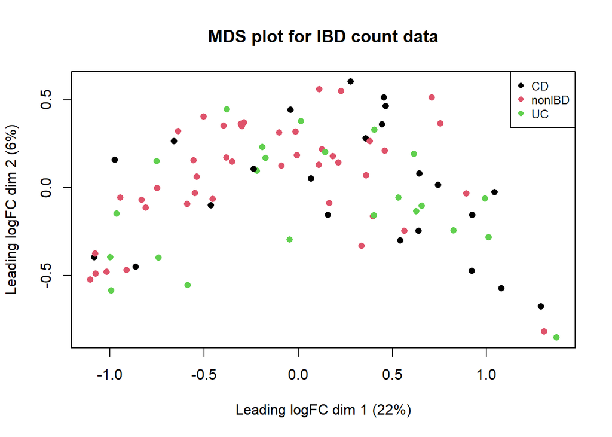

```r
plotMDS(y,
        # method = "bcv",
        main = "MDS plot for IBD count data",
        col = as.numeric(y$samples$group),
        labels = NULL,
        pch = 16)

legend("topright",
       as.character(unique(y$samples$group)),
       col=1:3,
       cex = 0.8,
       pch = 16)
```

### Step 6 Estimate the dispersions

The dispersion measures the biological variability of within-group variability, i.e., variability between replicates (or called inter-library variation) for that OTU.

For strongly abundant genes, the dispersion can be understood as a squared coefficient of variation: that is, a dispersion value of 0.01 indicates that the OTU’s abundance tends to differ by 10% between samples of the same treatment group.

Typically, the shape of the dispersion fit is an exponentially decaying curve. Fit a model in edgeR to estimate the dispersion as below:

1. Estimate the common dispersion The common dispersion measure will give an idea of overall variability across the OTUs for the data set.

Rename the variable to y1 and estimate common dispersion as below,

```r
y1 <- estimateCommonDisp(y, verbose = T)
```

```
## Disp = 7.98047 , BCV = 2.825
```

```r
names(y1) # output includes the estimate and additional elements in the edgeR object
```

```
## [1] "counts"            "samples"           "common.dispersion"
## [4] "pseudo.counts"     "pseudo.lib.size"   "AveLogCPM"
```

2. Fit a trend model to get a OTU wise dispersion If a trend model is not fit, `edgeR` by default uses the common dispersion as a trend. Once the model is fit, one can estimate OTU-wise (or, `tag-wise`) dispersion, which is a function of this model.

Each OTU will get its own unique dispersion estimate.

The OTU-wise (or, `tag-wise`) dispersion are squeezed toward the common value: a trended estimate computed by the “moving average” approach

```r
y1 <- estimateTagwiseDisp(y1)

names(y1)
```

```
##  [1] "counts"             "samples"            "common.dispersion"
##  [4] "pseudo.counts"      "pseudo.lib.size"    "AveLogCPM"
##  [7] "prior.df"           "prior.n"            "tagwise.dispersion"
## [10] "span"
```

Use `plotBCV()` function to plot the OTU-wise biological coefficient of variation (square root of dispersion) against log2-CPM

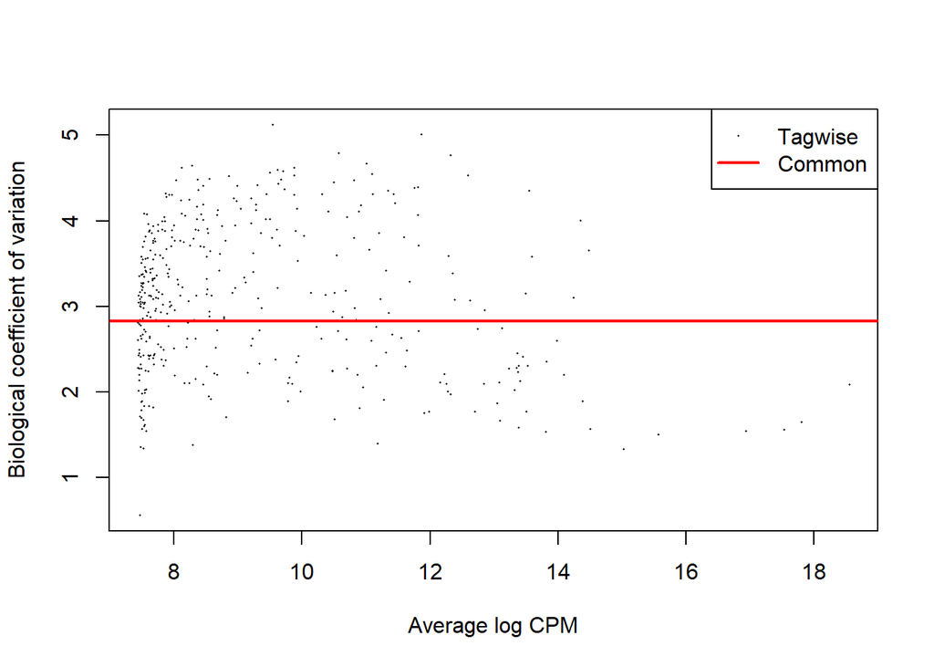

```r
plotBCV(y1)
```

3. Fit a generalized linear model to estimate the tag-wise dispersion

Alternatively, use GLM model to estimate the tag-wise dispersion estimate.

Define the design matrix prior to fitting GLM as follows,

```r
design <- model.matrix(~groups)

rownames(design) <- colnames(y)

design
```

```
##        (Intercept) groupsCD groupsUC
## 206538           1        1        0
## 206548           1        0        0
## 206561           1        1        0
## 206562           1        0        1
## 206570           1        0        1
## 206572           1        1        0
## 206605           1        0        0
## 206609           1        0        1
## 206615           1        1        0
## 206619           1        0        1
## 206621           1        0        1
## 206624           1        1        0
## 206628           1        0        1
## 206630           1        0        1
```

[output cut: 80 more lines]

Next, estimate OTU-wise dispersion over all OTUs, allowing for a possible abundance trend. The estimation is also robust against potential outlier OTUs.

```r
require(statmod)

y2 <- estimateDisp(y, design, robust = TRUE)

y2$common.dispersion
```

```
## [1] 12.7944
```

Plot the OTU-wise biological coefficient of variation (square root of dispersions) against log2-CPM

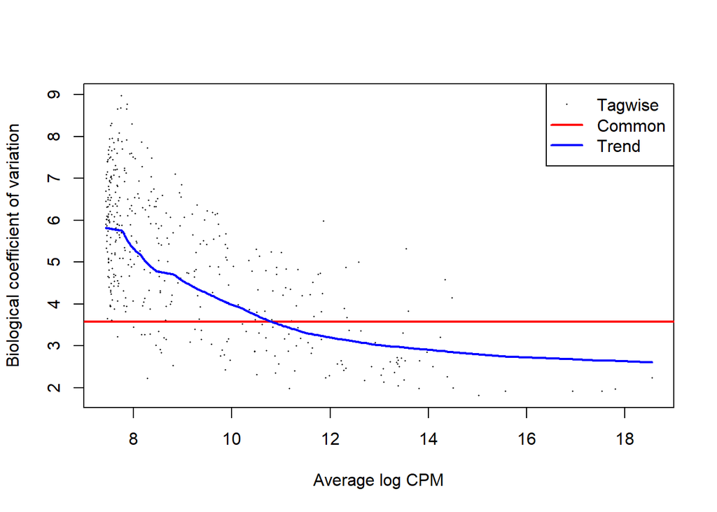

```r
plotBCV(y2)
```

The coefficient of biological variation (BCV) is the square root of dispersion.

The above plot indicates that the trended dispersion decreases with OTU abundance. At low logCPM, the dispersion are very large indeed.

Note that only the trended dispersion is used under the quasi-likelihood (QL) pipeline, whereas the tagwise and common estiamtes are not.

In the following, use `glmQLFit()` function to estimate the QL dispersion, and then visualize them with the `plotQLDisp()` function.

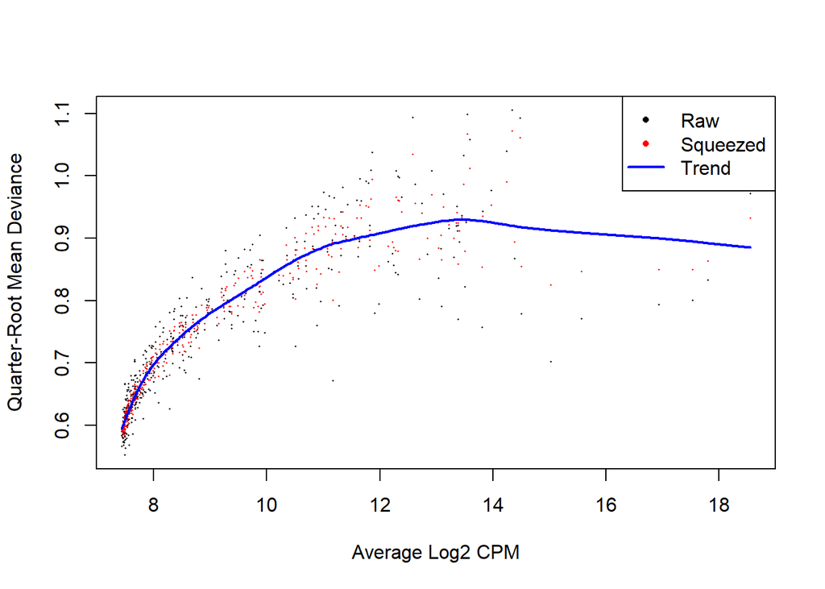

```r
fit <- glmQLFit(y2, design, robust = TRUE)

plotQLDisp(fit)
```

### Step 7 Test the differential abundance

Test the differentially abundant OTUs between conditions either using the function `exactTest()` or GLM approach.

```r
et_uc <- exactTest(y1, pair = c("nonIBD", "UC"))
topTags(et_uc)
```

```
## Comparison of groups:  UC-nonIBD
##               logFC    logCPM       PValue          FDR
## UncG3786  -5.125328 18.549024 2.074983e-06 0.0008341431
## Unc04zvf -10.314618 11.820268 6.206621e-05 0.0124753081
## Unc0402j  -4.197164  9.582012 5.690569e-04 0.0596966113
## Unc050mf  -3.161070 13.315332 8.529599e-04 0.0596966113
## Unc19563  -4.494488  9.207165 9.280649e-04 0.0596966113
## Unc003tx   5.310230  8.093913 9.381836e-04 0.0596966113
## UncSta97  -3.035149  9.778258 1.039493e-03 0.0596966113
## Gt8Met68  -9.541522 11.097853 1.488750e-03 0.0748096861
## Unc57731  -5.459861  8.511262 1.814544e-03 0.0749297266
## Unc81868  -8.279424 11.434767 2.100620e-03 0.0749297266
```

```r
et_cd <- exactTest(y1, pair = c("nonIBD", "CD"))
topTags(et_cd)
```

```
## Comparison of groups:  CD-nonIBD
##               logFC    logCPM       PValue          FDR
## Unc04zvf  -9.061994 11.820268 1.658622e-07 6.620606e-05
## UncG3786  -4.079709 18.549024 3.293834e-07 6.620606e-05
## Unc81868  -9.907093 11.434767 2.497900e-06 3.347186e-04
## Unc99918 -10.271265 12.586643 4.277499e-06 4.298887e-04
## Gt8Met68  -9.088631 11.097853 2.060146e-05 1.454884e-03
## Unc55486  -7.681858 10.410726 2.171468e-05 1.454884e-03
## Unc00f0g  -7.376027  9.282427 4.984917e-05 2.862767e-03
## Unc01hjq  -6.566782  9.492411 8.385323e-05 4.213625e-03
## Unc21180  -4.896615  9.120924 1.273148e-04 5.180675e-03
## Unc01i5a  -6.231016  9.278368 1.288725e-04 5.180675e-03
```

The test statistic is reported as p-value, which is the probability that a log fold changes as strong or even stronger as the observed one would be seen under the null hypothesis.

edgeR uses the Benjamini-Hochberg (BH) mehtod for adjusting the false discovery rate (FDR).

GLM is more feasible than exactTest() approach. Establish a design matrix to describe the treatment conditions using model.matrix().

### Step 8 Interpret the results of differential abundance analysis with diagnostic plots

Use MA-plot and volcano plot to help interpret the results of differential abundance analysis. - Volcano plot: illustrate relationship between effect size and p-value - MA-plot: log-fold change (M-values) against the log-average (A-values)

In edgeR, the function `plotSmear()` can visualize the differential abundance data to provide a useful overview for an experiment with a two-group comparison.

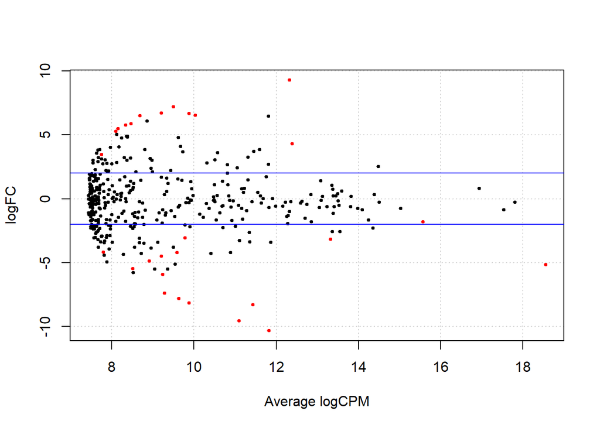

```r
da <- decideTestsDGE(et_uc, p.value = 0.1)

da_OTUs <- rownames(y1)[as.logical(da)]

plotSmear(et_uc, de.tags = da_OTUs, cex = 0.5)
abline(h = c(-2, 2), col="blue")
```

In the MA-plot, red points represent those OTUs with adjusted p-value less than 0.1. The horizontal blue lines show 4-fold changes.

Volcano plot is an effective way to summarize both fold-change and a measure of statistical test, usually with a p-value. It is a scatter-plot of the negative log10-transformed p-values from the OTU-specific test (on the y-axis) against the log2 fold change (on the x-axis).

```r
tab <- data.frame(logFC = et_uc$table[,1],
                  negLogPval = -log10(et_uc$table[ ,3]))

head(tab)
```

```
##       logFC negLogPval
## 1  2.914683  1.3299770
## 2 -1.754789  0.4655102
## 3  1.998530  0.4435554
## 4  0.245643  0.0000000
## 5 -5.921358  2.3493607
## 6 -1.793330  0.6121514
```

Use the function par() and plot() to generate the volcano plot.

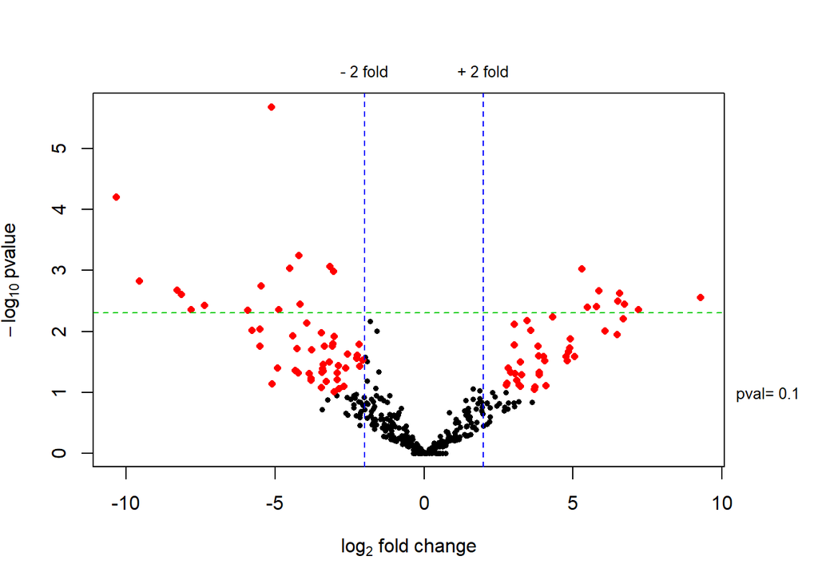

```r
par(mar=c(5, 4, 4, 4))
plot(tab, pch = 16,
     cex = 0.6,
     xlab = expression(log[2]~fold~change),
     ylab=expression(-log[10]~pvalue))

lfc <- 2

pval <- 0.1

sig_OTUs <- (abs(tab$logFC)> lfc & tab$negLogPval > -log10(pval))

points(tab[sig_OTUs, ], pch=16, cex=0.8, col="red")
abline(h = -log(pval), col ="green3", lty=2)
abline(v = c(-lfc, lfc), col="blue", lty=2)
mtext(paste("pval=", pval), side =4, at = -log10(pval),
      cex=0.8, line=0.5, las=1)
mtext(c(paste("-", lfc, "fold"),
        paste("+", lfc, "fold")),
      side =3,
      at=c(-lfc, lfc),
      cex= 0.8,
      line = 0.5)
```